# Dow Data Challenge

S. J. Qin, S. Guo, Z. Li, L. H. Chiang, I. Castillo, B. Braun and Z. Wang, "Integration of process knowledge and statistical learning for the Dow data challenge problem", Computers & Chemical Engineering, 153, 107451 (2021). [doi:10.1016/j.compchemeng.2021.107451](http://doi.org/10.1016/j.compchemeng.2021.107451)

```python
import pandas as pd
from pylab import *
from matplotlib.ticker import MaxNLocator
from datetime import datetime
```

## Import Data

```python
url = 'http://egr.msu.edu/~scb/courses/EGR891/ImpurityDataset_Training.xlsx'
urlv = 'http://egr.msu.edu/~scb/courses/EGR891/ImpurityDataset_Validation.xlsx'

df=pd.read_excel(url)
dfv=pd.read_excel(urlv)
df.head()
```

|  | Date | x1:Primary Column Reflux Flow | x2:Primary Column Tails Flow | x3:Input to Primary Column Bed 3 Flow | x4:Input to Primary Column Bed 2 Flow | x5:Primary Column Feed Flow from Feed Column | x6:Primary Column Make Flow | x7:Primary Column Base Level | x8:Primary Column Reflux Drum Pressure | x9:Primary Column Condenser Reflux Drum Level | ... | x36: Feed Column Recycle Flow | x37: Feed Column Tails Flow to Primary Column | x38: Feed Column Calculated DP | x39: Feed Column Steam Flow | x40: Feed Column Tails Flow | Avg_Reactor_Outlet_Impurity | Avg_Delta_Composition Primary Column | y:Impurity | Primary Column Reflux/Feed Ratio | Primary Column Make/Reflux Ratio |
| --- | --- | --- | --- | --- | --- | --- | --- | --- | --- | --- | --- | --- | --- | --- | --- | --- | --- | --- | --- | --- | --- |
| 0 | 2015-12-01 00:00:00 | 327.813 | 45.7920 | 2095.06 | 2156.01 | 98.5005 | 95.4674 | 54.3476 | 41.0121 | 52.2353 | ... | 62.8707 | 45.0085 | 66.6604 | 8.68813 | 99.9614 | 5.38024 | 1.49709 | 1.77833 | 3.32803 | 0.291226 |
| 1 | 2015-12-01 01:00:00 | 322.970 | 46.1643 | 2101.00 | 2182.90 | 98.0014 | 94.9673 | 54.2247 | 41.0076 | 52.5378 | ... | 62.8651 | 45.0085 | 66.5496 | 8.70683 | 99.8637 | 5.33345 | 1.51392 | 1.76964 | 3.29556 | 0.294044 |
| 2 | 2015-12-01 02:00:00 | 319.674 | 45.9927 | 2102.96 | 2151.39 | 98.8229 | 96.0785 | 54.6130 | 41.0451 | 52.0159 | ... | 62.8656 | 45.0085 | 66.0599 | 8.69269 | 100.2490 | 5.37677 | 1.50634 | 1.76095 | 3.23481 | 0.300552 |
| 3 | 2015-12-01 03:00:00 | 327.223 | 46.0960 | 2101.37 | 2172.14 | 98.7733 | 96.1223 | 54.9153 | 41.0405 | 52.9477 | ... | 62.8669 | 45.0085 | 67.9697 | 8.70482 | 100.3200 | 5.32315 | 1.47935 | 1.75226 | 3.31287 | 0.293752 |
| 4 | 2015-12-01 04:00:00 | 331.177 | 45.8493 | 2114.06 | 2157.77 | 99.3231 | 94.7521 | 54.0925 | 40.9934 | 53.0507 | ... | 62.8673 | 45.0085 | 67.6454 | 8.70077 | 100.6590 | 5.28227 | 1.44489 | 1.74357 | 3.33435 | 0.286107 |

5 rows × 46 columns

### Clean data

#### There are a lot of problems with this data 🤦‍♂️

- "!" where there should be numbers
- "NaN"
- A period during which the operating conditions changed
- A period where a flow rate was abnormally low
- two temperature sensors were alternatingly switched on and off
- the impurity sampling was sparse and was linearly interpolated to match x sampling

!pip install missingno

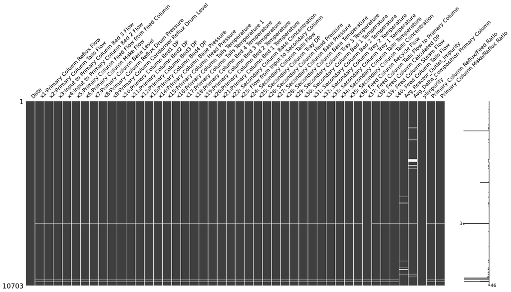

```python
import missingno as msno
msno.matrix(df)
plt.show()
```

#### Find columns containing '!'

```python
cols_with_exclamation = [col for col in df.columns if df[col].astype(str).str.contains('!').any()]

# Replace '!' with NaN and convert to float
for col in cols_with_exclamation:
    df[col] = pd.to_numeric(df[col].mask(df[col] == '!'), errors='coerce').astype('float64')
```

#### Drop rows with >50% missing

```python
threshold = 0.5
df_cleaned = df.dropna(thresh=int(threshold * len(df.columns)), axis=0)
```

#### interpolate columns with missing data

```python
df_cleaned = df_cleaned.interpolate()
```

```python
df_cleaned.isna().any().any()
```

```
np.False_
```

### Define Datasets

```python
X = df_cleaned.loc[:,'x1:Primary Column Reflux Flow':'x40: Feed Column Tails Flow']
Y = df_cleaned.loc[:,'y:Impurity'].values
```

```python
X.shape, Y.shape
```

```
((10684, 40), (10684,))
```

[figure not shown]

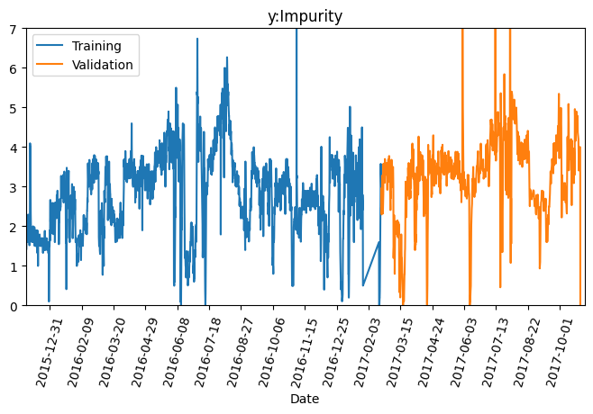

```python
figure(figsize=[8,4])
plot(df_cleaned['Date'], Y, label='Training')
plot(dfv['Date'], dfv['y:Impurity'], label='Validation')
ylim(0,7)
xlim(datetime(2015, 12, 1), datetime(2017, 11, 1))
xticks(rotation=75, size=10)
xlabel('Date')
title('y:Impurity')
gca().xaxis.set_major_locator(MaxNLocator(nbins=20))
legend()
show()
```

## 3. Data pre-analysis with process knowledge

### 3.1. Outlier removal

[figure not shown]

### Scaled PCA

```python
from sklearn.preprocessing import StandardScaler
from sklearn.decomposition import PCA

scaler = StandardScaler()
X_scaled = scaler.fit_transform(X)

pca = PCA(n_components=0.95, svd_solver="full")
X_pca = pca.fit_transform(X_scaled)
```

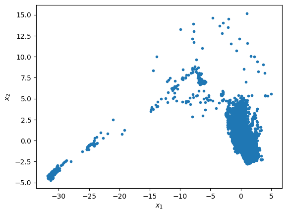

```python
plot(X_pca[:,0],-X_pca[:,1],'.')
xlabel('$x_1$'), ylabel('$x_2$')
show()
```

This data shows two distinct trends. To identify which feature is causing this issue, we would need to separate out results into two forms (linear line and blob around zero) and look for correlations or trends in that data.

```python
pca.explained_variance_ratio_, sum(pca.explained_variance_ratio_)
```

```
(array([0.5859767 , 0.10411915, 0.0576029 , 0.04377263, 0.03404058,
        0.03007132, 0.02536355, 0.02264662, 0.0197315 , 0.01538206,
        0.00873269, 0.0071239 ]),
 np.float64(0.9545636004815449))
```

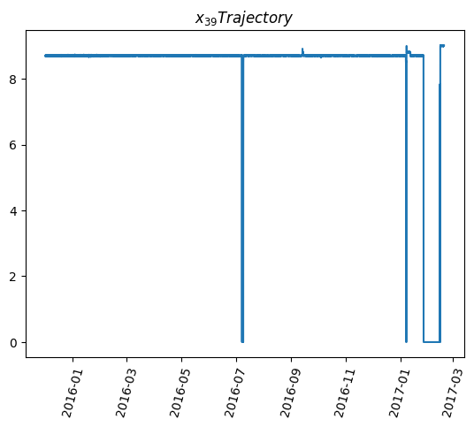

```python
plot(df_cleaned['Date'], df_cleaned['x39: Feed Column Steam Flow'])
title('$x_{39} Trajectory$')
xticks(rotation=75, size=10)
show()
```

```python
x39_flow = df_cleaned['x39: Feed Column Steam Flow'].values

x39_is_zero = x39_flow < 0.01

x39_nonzero = ~x39_is_zero

dff = df_cleaned[x39_nonzero].copy()

X = df_cleaned.loc[:,'x1:Primary Column Reflux Flow':'x40: Feed Column Tails Flow']

X_scaled = scaler.fit_transform(X)

pca = PCA(n_components=0.95, svd_solver="full")

X_pca = pca.fit_transform(X_scaled)
```

#### Calculate T2 oval

```python
from pca_monitoring import t2_ellipse
t2xy = t2_ellipse(pca, X_scaled.shape[0], alpha=0.95, npts=100)
```

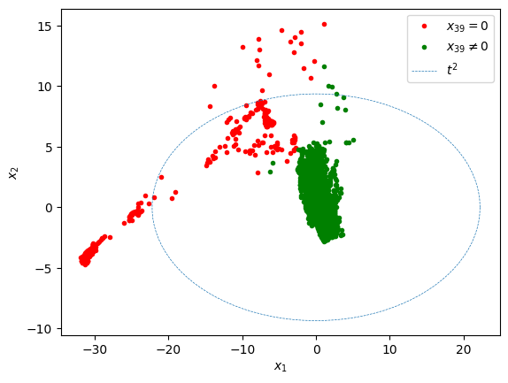

```python
plot(X_pca[x39_is_zero,0], -X_pca[x39_is_zero,1], '.r',
      label='$x_{39} = 0$')
plot(X_pca[~x39_is_zero,0],-X_pca[~x39_is_zero,1], '.g',
     label=r'$x_{39} \neq 0$')
plot(*t2xy,'--', lw=0.5 , label='$t^2$')
legend(bbox_to_anchor=(1, 1))
xlabel('$x_1$'), ylabel('$x_2$')
show()
```

#### Filter out x39 = 0 and redo PCA

```python
dff = df_cleaned[df_cleaned['x39: Feed Column Steam Flow'] >= 0.01].copy()

X = dff.loc[:,'x1:Primary Column Reflux Flow':'x40: Feed Column Tails Flow']

Y = dff.loc[:,'y:Impurity'].values

X_scaled = scaler.fit_transform(X)
pca = PCA(n_components=0.95, svd_solver="full")
X_pca = pca.fit_transform(X_scaled)
```

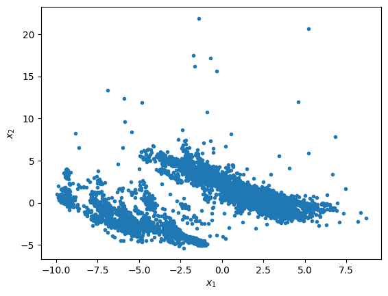

```python
plot(X_pca[:,0],-X_pca[:,1],'.')
xlabel('$x_1$'), ylabel('$x_2$')
show()
```

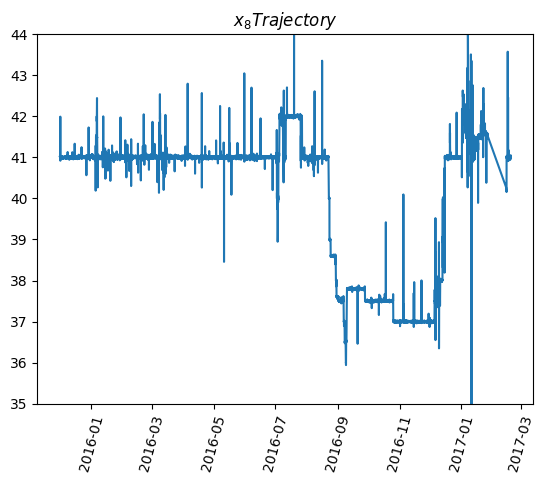

```python
plot(dff['Date'], dff['x8:Primary Column Reflux Drum Pressure'])
title('$x_{8} Trajectory$')
xticks(rotation=75, size=10)
ylim(35,44)
show()
```

#### Filter out low values of x8

```python
x8_is_low = dff['x8:Primary Column Reflux Drum Pressure'].values < 40
```

```python
t2xy = t2_ellipse(pca, X_scaled.shape[0], alpha=0.95, npts=100)
```

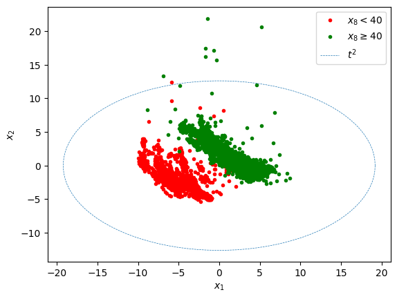

```python
plot(X_pca[x8_is_low,0], -X_pca[x8_is_low,1], '.r',
      label='$x_{8} < 40$')
plot(X_pca[~x8_is_low,0],-X_pca[~x8_is_low,1], '.g',
      label=r'$x_{8} \geq 40$')
plot(*t2xy,'--', lw=0.5 , label='$t^2$')
legend(bbox_to_anchor=(1, 1))
xlabel('$x_1$'), ylabel('$x_2$')

show()
```

#### Filter out from 8/22/2016 to 12/16/2016

> Process operation knowledge conﬁrmed that the operating conditions from 8/22/2016 to 12/16/2016 was changed due to a business decision that will not recur in subsequent operations. Therefore, this period of data will not be used for model training.

```python
start = '2016-08-22'
end   = '2016-12-16'

datemask = (dff['Date'] < start) | (dff['Date'] > end)

dff = dff[datemask].copy().reset_index(drop=True)

dff.shape
```

```
(7434, 46)
```

That's a lot of data removed ‼️

```python
X = dff.loc[:,'x1:Primary Column Reflux Flow':'x40: Feed Column Tails Flow']
Y = dff.loc[:,'y:Impurity'].values

X.shape, Y.shape
```

```
((7434, 40), (7434,))
```

```python
X_scaled = scaler.fit_transform(X)
pca = PCA(n_components=0.95, svd_solver="full")
X_pca = pca.fit_transform(X_scaled)
pca.explained_variance_ratio_, sum(pca.explained_variance_ratio_)
```

```
(array([0.36104546, 0.10487675, 0.0746643 , 0.07065897, 0.06377484,
        0.04699806, 0.04085042, 0.03194105, 0.02771904, 0.02455773,
        0.02357474, 0.01997315, 0.01796525, 0.01360344, 0.01276327,
        0.00980165, 0.00849665]),
 np.float64(0.9532647666190237))
```

```python
t2xy = t2_ellipse(pca, X_scaled.shape[0], alpha=0.95, npts=100)
```

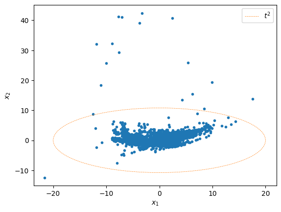

```python
plot(X_pca[:,0],-X_pca[:,1],'.')
plot(*t2xy,'--', lw=0.5 , label='$t^2$')
xlabel('$x_1$'), ylabel('$x_2$')
legend(bbox_to_anchor=(1, 1))
show()
```

So at this point we could filter out these outliers if we choose.

### 3.2 Alternating Temperature measurements x16, x17

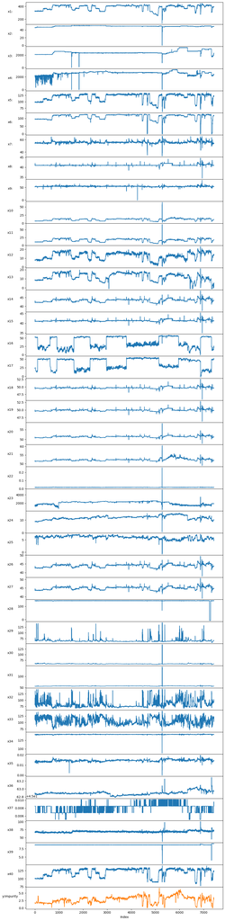

```python
dfX = dff.loc[:,:'x40: Feed Column Tails Flow']

fig, axes = plt.subplots(len(dfX.columns[1:])+1, 1,
                         figsize=(10, len(dfX.columns)),
                         sharex=True)

for ax, col in zip(axes, dfX.columns[1:]):
    ax.plot(dfX.index, dfX[col])
    ax.set_ylabel(col[:3],rotation=0, labelpad=15)
    ax.tick_params(axis='y', labelsize=10)
    ax.yaxis.set_label_coords(-0.08, 0.5)

ax = axes[-1]
ax.plot(dff.index, dff['y:Impurity'],'C1')
ax.set_ylabel('y:Impurity',rotation=0, labelpad=15, size=10)
ax.tick_params(axis='y', labelsize=10)
ax.yaxis.set_label_coords(-0.08, 0.5)

axes[-1].set_xlabel('Index')
plt.tight_layout()
fig.subplots_adjust(hspace=0)
plt.show()
```

#### Create new variables

```python
x16 = dff['x16:Primary Column Tails Temperature']
x17 = dff['x17:Primary Column Tails Temperature 1']

dff['x16x17L'] = np.minimum(x16, x17)
dff['x16x17H'] = np.maximum(x16, x17)

# sort columns
dff = dff[sorted(dff.columns)]
```

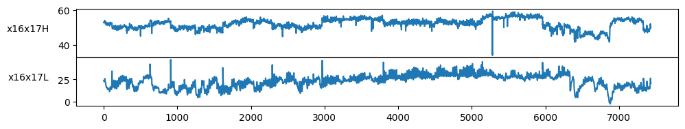

```python
fig, axes = plt.subplots(2, 1,
                         figsize=(10, 2),
                         sharex=True)

ax = axes[0]
ax.plot(dff.index, dff['x16x17H'])
ax.set_ylabel('x16x17H',rotation=0, labelpad=15)
ax.tick_params(axis='y', labelsize=10)
ax.yaxis.set_label_coords(-0.08, 0.5)

ax = axes[1]
ax.plot(dff.index, dff['x16x17L'])
ax.set_ylabel('x16x17L',rotation=0, labelpad=15)
ax.tick_params(axis='y', labelsize=10)
ax.yaxis.set_label_coords(-0.08, 0.5)

plt.tight_layout()
fig.subplots_adjust(hspace=0)
plt.show()
```

### 3.3. Detecting interpolated impurity data points

```python
import plotly.graph_objects as go

fig = go.Figure()
fig.add_trace(go.Scatter(x = dff['Date'],
                         y= dff['y:Impurity'],
                         mode='markers',
                         marker=dict(size=4)
                        ))

fig.update_layout(title='y:Impurity', xaxis_title='Time', yaxis_title='Value')
fig.show()
```

[output not shown]

```python
def remove_interpolated_points(t_datetime, y, slope_tol=1e-5):
    """
    Remove linearly interpolated points by detecting constant-slope segments.


    """
    t_datetime = pd.to_datetime(t_datetime)
    t_numeric = (t_datetime - t_datetime.iloc[0]).dt.total_seconds().values
    y = np.asarray(y, dtype=float)

    if len(y) <= 2:
        return t_datetime.values, y

    slopes = np.diff(y) / np.diff(t_numeric)

    slope_changes = np.abs(np.diff(slopes))

    keep = np.ones(len(y), dtype=bool)
    for i in range(len(slope_changes)):
        if slope_changes[i] <= slope_tol:
            keep[i + 1] = False

    return t_datetime.values[keep], y[keep], keep
```

```python
t_datetime = dff['Date']
t = (t_datetime - t_datetime[0]).dt.total_seconds().values / 3600
y = dff['y:Impurity']

tk, yk, lin_mask = remove_interpolated_points(t_datetime, y, slope_tol=1e-5)
print(f"Original: {len(y)} points → Filtered: {len(yk)} points ({100*len(yk)/len(y):.1f}% retained)")
```

```
Original: 7434 points → Filtered: 1036 points (13.9% retained)
```

```python
fig = go.Figure()
fig.add_trace(go.Scatter(x = dff['Date'],
                         y= dff['y:Impurity'],
                         mode='markers',
                         marker=dict(size=4),
                         name='Original',
                        ))

fig.add_trace(go.Scatter(x = tk,
                         y= yk,
                         mode='markers',
                         marker=dict(
                            size=6,
                            color='rgba(255,255,255,0)',
                            line=dict(color='orange', width=0.5)
                         ),
                         name='Non-linear',
                         ))

fig.update_layout(title='y:Impurity',
                    width=800,   # pixels
                    height=400,   # pixels
                    xaxis_title='Time',
                    yaxis_title='Value',
                    legend=dict(
                      x=1.05,  y=1,     # 0=bottom, 1=top
                      xanchor='left',  # 'left', 'center', 'right'
                      yanchor='top'    # 'top', 'middle', 'bottom'
                     ))
fig.show()
```

[output not shown]

```python
import re

df_f2 = dff[lin_mask].copy().reset_index(drop=True)

x_cols = [col for col in df_f2.columns if col.startswith('x')]

def x_sort_key(c):
    match = re.match(r'^x(\d+):', c)
    if match:
        return (0, int(match.group(1)), c)
    return (1, c)

x_cols = sorted(x_cols, key=x_sort_key)

X = df_f2[x_cols].values
Y = df_f2['y:Impurity'].values

X_scaled = scaler.fit_transform(X)

df_f2.shape, X.shape, Y.shape
```

```
((1036, 48), (1036, 42), (1036,))
```

Now we're down to only ~1000 samples ‼️

```python
import re


def sort_key(c):
    if c.startswith('x'):

        return (0, int(re.match(r'x(\d+)', c).group(1)))
    if c.startswith('Avg'):

        return (1, c)
    if c.startswith('y'):

        return (2, c)

    return (3, c)


d = df_f2.loc[:,'x10:Primary Column Bed1 DP':'y:Impurity']
d = d[sorted(d.columns, key=sort_key)]
```

### Correlation Plot

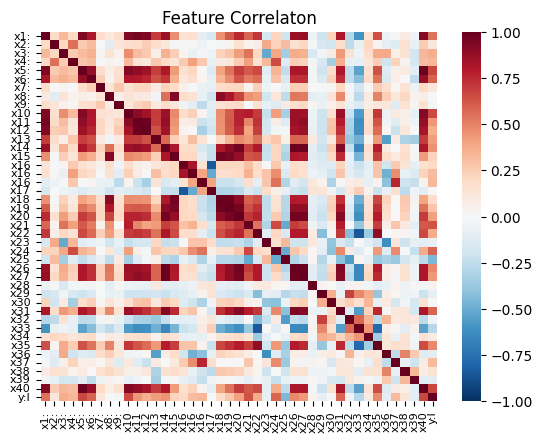

```python
import seaborn as sns
import matplotlib.pyplot as plt
sns.heatmap(d.corr(), cmap='RdBu_r', vmin=-1, vmax=1, fmt='.2f',
           xticklabels=[c[:3] for c in d.columns],
           yticklabels=[c[:3] for c in d.columns], )
plt.tick_params(labelsize=8)
title('Feature Correlaton')
plt.show()
```

Qin et al. have similar results, but my results still struggle with missing some interpolated points. Most notably, Qin et al deleted many "outlier" points when they showed unusual values for the subplots for each sensor (x1, etc.). I think that this is a mistake, as it can be seen that some of these peaks are actually plateaus, lasting for 6 hours or so. This seems like it is more likely a deliberate attempt to modify an aspect of the reactor, and observe if it produces a change in the impurity concentration.